# Practical Machine Learning Project

## Question

Can we predict the manner in which people lift barbells, using the data from sensors on their belt, arm, forearm and on the dumbell itself?

## Feature selection

The dataset contains 19622 observations of 160 variables. The objective is to predict “classe”. After inspecting the variables using str(dt) we first exclude the columns that are not relevant, and variables with incomplete measurements. Then split the dataset into training and testing sets. * Note: Each person is likely to make the movements in a slightly different way. So if we use the name in the model (by turning it into 6 indicator variables) we will probably get a better fit. But that model would not generalise as well.

```r
dt = read.csv("pml-training.csv", na.strings=c("","NA"))
tt = read.csv("pml-testing.csv", na.strings=c("","NA"))
dts = dt[,c(8:160)]

dts = dts[,apply(dts, 2, function(x) !any(is.na(x)))]
inTrain <- createDataPartition(y=dts$classe, p=6/10, list=FALSE)
trn <- dts[inTrain,]
tst <- dts[-inTrain,]
summary(complete.cases(trn))
```

```
##    Mode    TRUE    NA's
## logical   11776       0
```

## Model selection

Three classification methods were tried: Recursive Partitioning and Regression Trees, Random Forrest and Boosting. Random Forrest and Boosting had significantly higher accuracy than rpart. The cross-validation parameters were fine-tuned to improve accuracy further. Random Forrest and Boosting worked well with 5 folds repeated 3 times. Only marginal improvements were obtained with more folds or repetitions.

```r
set.seed(3223)
registerDoMC(cores = 7)

model_rp <- train(classe ~ ., data=trn, method="rpart", trControl=trainControl(method="repeatedcv", number=5, repeats = 3))

model_rf <- train(classe ~ ., data=trn, method="rf", trControl=trainControl(method="repeatedcv", number=5, repeats = 3))

model_bs <- train(classe ~ ., data=trn, method="gbm", verbose=FALSE, trControl=trainControl(method="repeatedcv", number=5, repeats = 3))

confusionMatrix(model_rp)
```

```
## Cross-Validated (5 fold, repeated 3 times) Confusion Matrix
##
## (entries are percentual average cell counts across resamples)
##
##           Reference
## Prediction    A    B    C    D    E
##          A 24.1  7.3  6.4  6.4  2.2
##          B  1.3  6.9  0.9  3.2  3.0
##          C  2.4  4.1  9.9  5.5  3.9
##          D  0.3  0.8  0.2  1.3  0.7
##          E  0.3  0.2  0.0  0.1  8.7
##
##  Accuracy (average) : 0.5091
```

```r
confusionMatrix(model_rf)
```

```
## Cross-Validated (5 fold, repeated 3 times) Confusion Matrix
##
## (entries are percentual average cell counts across resamples)
##
##           Reference
## Prediction    A    B    C    D    E
##          A 28.4  0.2  0.0  0.0  0.0
##          B  0.0 19.0  0.1  0.0  0.0
##          C  0.0  0.1 17.2  0.3  0.1
##          D  0.0  0.0  0.1 16.1  0.1
##          E  0.0  0.0  0.0  0.0 18.2
##
##  Accuracy (average) : 0.989
```

```r
confusionMatrix(model_bs)
```

```
## Cross-Validated (5 fold, repeated 3 times) Confusion Matrix
##
## (entries are percentual average cell counts across resamples)
##
##           Reference
## Prediction    A    B    C    D    E
##          A 27.9  0.7  0.0  0.0  0.0
##          B  0.4 18.0  0.6  0.1  0.2
##          C  0.1  0.6 16.6  0.6  0.2
##          D  0.0  0.0  0.2 15.6  0.2
##          E  0.0  0.0  0.0  0.1 17.7
##
##  Accuracy (average) : 0.9582
```

## Out of sample error

```r
confusionMatrix(predict(model_rp, tst), tst$classe)
```

```
## Confusion Matrix and Statistics
##
##           Reference
## Prediction    A    B    C    D    E
##          A 2003  651  618  577  203
##          B   35  517   38  229  176
##          C  163  350  712  480  382
##          D    0    0    0    0    0
##          E   31    0    0    0  681
##
## Overall Statistics
##
##                Accuracy : 0.4987
##                  95% CI : (0.4876, 0.5099)
##     No Information Rate : 0.2845
##     P-Value [Acc > NIR] : < 2.2e-16
##
##                   Kappa : 0.3452
##  Mcnemar's Test P-Value : NA
##
## Statistics by Class:
##
##                      Class: A Class: B Class: C Class: D Class: E
## Sensitivity            0.8974  0.34058  0.52047   0.0000  0.47226
## Specificity            0.6350  0.92446  0.78774   1.0000  0.99516
## Pos Pred Value         0.4943  0.51960  0.34116      NaN  0.95646
## Neg Pred Value         0.9396  0.85389  0.88609   0.8361  0.89333
## Prevalence             0.2845  0.19347  0.17436   0.1639  0.18379
## Detection Rate         0.2553  0.06589  0.09075   0.0000  0.08680
## Detection Prevalence   0.5164  0.12682  0.26600   0.0000  0.09075
## Balanced Accuracy      0.7662  0.63252  0.65411   0.5000  0.73371
```

```r
confusionMatrix(predict(model_rf, tst), tst$classe)
```

```
## Confusion Matrix and Statistics
##
##           Reference
## Prediction    A    B    C    D    E
##          A 2231   16    0    0    0
##          B    1 1499   12    1    1
##          C    0    3 1349   28    1
##          D    0    0    7 1254    2
##          E    0    0    0    3 1438
##
## Overall Statistics
##
##                Accuracy : 0.9904
##                  95% CI : (0.988, 0.9925)
##     No Information Rate : 0.2845
##     P-Value [Acc > NIR] : < 2.2e-16
##
##                   Kappa : 0.9879
##  Mcnemar's Test P-Value : NA
##
## Statistics by Class:
##
##                      Class: A Class: B Class: C Class: D Class: E
## Sensitivity            0.9996   0.9875   0.9861   0.9751   0.9972
## Specificity            0.9971   0.9976   0.9951   0.9986   0.9995
## Pos Pred Value         0.9929   0.9901   0.9768   0.9929   0.9979
## Neg Pred Value         0.9998   0.9970   0.9971   0.9951   0.9994
## Prevalence             0.2845   0.1935   0.1744   0.1639   0.1838
## Detection Rate         0.2843   0.1911   0.1719   0.1598   0.1833
## Detection Prevalence   0.2864   0.1930   0.1760   0.1610   0.1837
## Balanced Accuracy      0.9984   0.9926   0.9906   0.9869   0.9984
```

```r
confusionMatrix(predict(model_bs, tst), tst$classe)
```

```
## Confusion Matrix and Statistics
##
##           Reference
## Prediction    A    B    C    D    E
##          A 2204   57    0    1    3
##          B   17 1419   48    4   19
##          C    5   41 1306   51   18
##          D    3    1   14 1224   22
##          E    3    0    0    6 1380
##
## Overall Statistics
##
##                Accuracy : 0.9601
##                  95% CI : (0.9555, 0.9643)
##     No Information Rate : 0.2845
##     P-Value [Acc > NIR] : < 2.2e-16
##
##                   Kappa : 0.9495
##  Mcnemar's Test P-Value : < 2.2e-16
##
## Statistics by Class:
##
##                      Class: A Class: B Class: C Class: D Class: E
## Sensitivity            0.9875   0.9348   0.9547   0.9518   0.9570
## Specificity            0.9891   0.9861   0.9822   0.9939   0.9986
## Pos Pred Value         0.9731   0.9416   0.9191   0.9684   0.9935
## Neg Pred Value         0.9950   0.9844   0.9904   0.9906   0.9904
## Prevalence             0.2845   0.1935   0.1744   0.1639   0.1838
## Detection Rate         0.2809   0.1809   0.1665   0.1560   0.1759
## Detection Prevalence   0.2887   0.1921   0.1811   0.1611   0.1770
## Balanced Accuracy      0.9883   0.9604   0.9685   0.9728   0.9778
```

## Summary and Conclusion

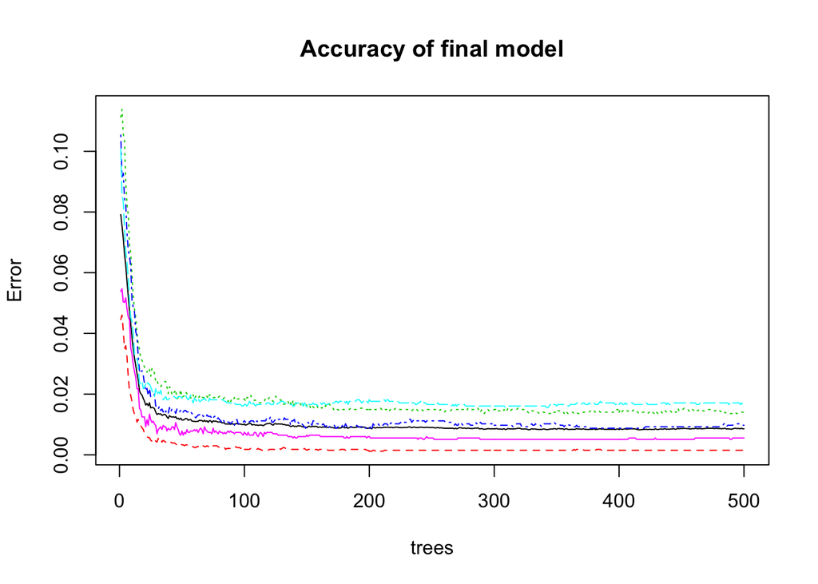

```r
plot(model_rf$finalModel, main="Accuracy of final model")
```

```r
tts = tt[,c(8:160)]
tts = tts[,apply(tts, 2, function(x) !any(is.na(x)))]
# predict(model_rf, tts)
```